# Project-Metaphors

# And here at the following densities plots it is clear, that “tomber” is the most frequent verb in all analysed cases. How could this statement be proved? In the x-axis scale there are numbers of nouns with their frequencies (from 0-300 nouns, because in general about 900 nouns are analysed). In the y-axis there are probability densities instead of frequencies.

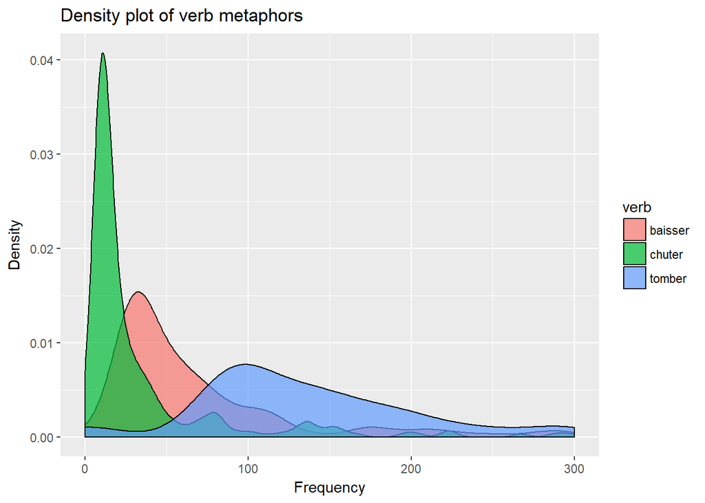

```r
# Density plot for Frequency1
ggplot(data1French[data1French$metaphor == '1', ], aes(x = frequency1))+
  geom_density(aes(fill = verb), alpha = 0.7)+
  scale_y_continuous('Density')+
  scale_x_continuous('Frequency', limits = c(0, 300))+
  ggtitle('Density plot of verb metaphors')
```

# French. However, to analyse the whole situation, it is better to analyse each of three verbs.

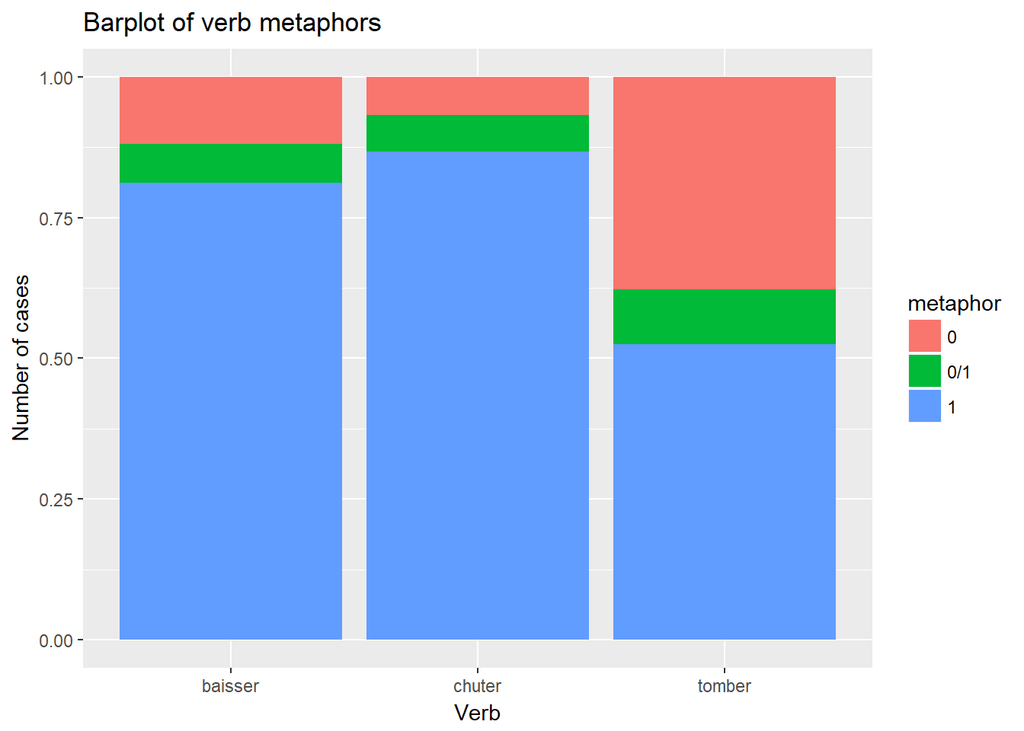

```r
ggplot(data1French[is.na(data1French$metaphor) == F, ], aes(verb))+
  geom_bar(aes(fill = metaphor), position = position_fill())+
  scale_y_continuous('Number of cases')+
  scale_x_discrete('Verb')+
  ggtitle('Barplot of verb metaphors')
```

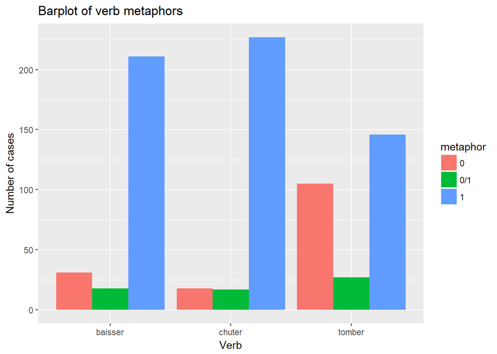

```r
ggplot(data1French[is.na(data1French$metaphor) == F, ], aes(verb))+
  geom_bar(aes(fill = metaphor), position = position_dodge())+
  scale_y_continuous('Number of cases')+
  scale_x_discrete('Verb')+
  ggtitle('Barplot of verb metaphors')
```

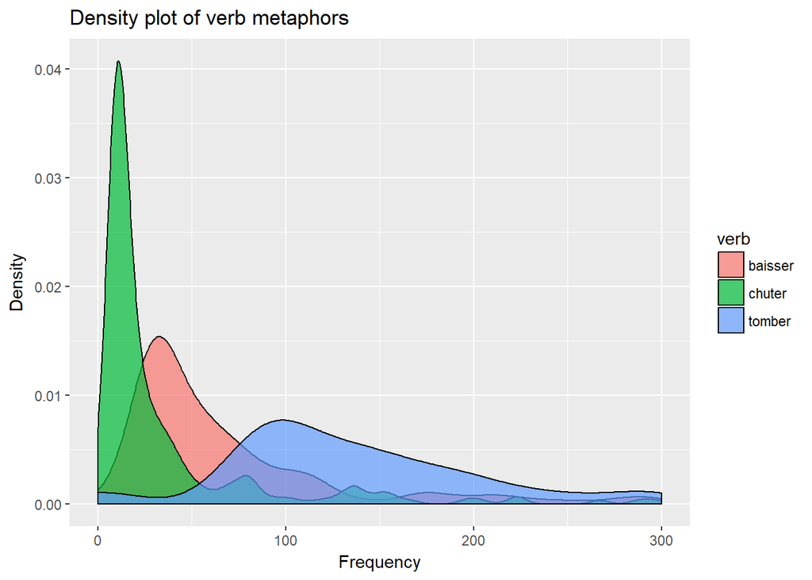

```r
ggplot(data1French[data1French$metaphor == '1', ], aes(x = frequency1))+
  geom_density(aes(fill = verb), alpha = 0.7)+
  scale_y_continuous('Density')+
  scale_x_continuous('Frequency', limits = c(0, 300))+
  ggtitle('Density plot of verb metaphors')
```

# Spanish blog. Firstly, I would like to analyse the categorical data of Spanish metaphors. As it could be seen, all three verbs show very wide combinatory. However, at this moment, we are not so interested in general numbers as in every field of metaphors.

```r
table(data2Spanish$verb, data2Spanish$metaphor) # contingency table
```

```
##
##               0 0/1   1
##   bajar      30  44 218
##   caer       70  37 187
##   descender  59  41 192
```

# Let’s just have a look at frequencies of nouns (metaphorical). Here there are only numbers, which will be then visualised.

```r
data2Spanish$frequency1[data2Spanish$metaphor == '1']
```

```
##   [1]   3.662   2.241   2.141   2.006   1.615   1.437   1.306   1.272
##   [9]   1.218   1.218   1.212   1.199   1.149   1.031 972.000 959.000
##  [17] 955.000 861.000 848.000 803.000 680.000 666.000 627.000 618.000
##  [25] 592.000 587.000 576.000 561.000 551.000 549.000 547.000 504.000
##  [33] 501.000 491.000 430.000 425.000 423.000 409.000 405.000 404.000
##  [41] 398.000 396.000 393.000 391.000 388.000 386.000 374.000 360.000
##  [49] 357.000 352.000 341.000 339.000 337.000 331.000 329.000 316.000
##  [57] 315.000 309.000 301.000 298.000 295.000 295.000 287.000 281.000
##  [65] 275.000 272.000 269.000 267.000 259.000 256.000 254.000 252.000
##  [73] 250.000 250.000 246.000 246.000 244.000 244.000 244.000 243.000
##  [81] 242.000 241.000 241.000 239.000 239.000 239.000 236.000 235.000
##  [89] 233.000 228.000 227.000 218.000 214.000 214.000 212.000 208.000
##  [97] 207.000 205.000 205.000 204.000 203.000 202.000 199.000 194.000
## [105] 194.000 193.000 193.000 192.000 192.000 191.000 187.000 187.000
## [113] 187.000 186.000 185.000 183.000 183.000 181.000 178.000 175.000
```

[output cut: 61 more lines]

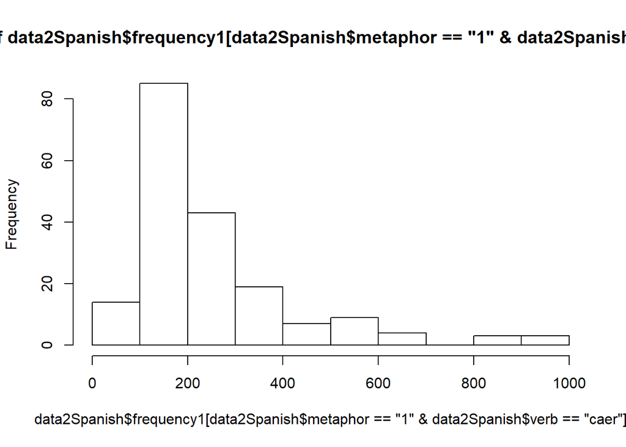

```r
hist(data2Spanish$frequency1[data2Spanish$metaphor == '1' & data2Spanish$verb == 'caer'])
```

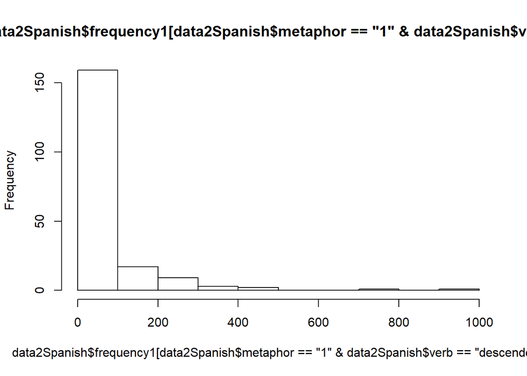

```r
hist(data2Spanish$frequency1[data2Spanish$metaphor == '1' & data2Spanish$verb == 'descender'])
```

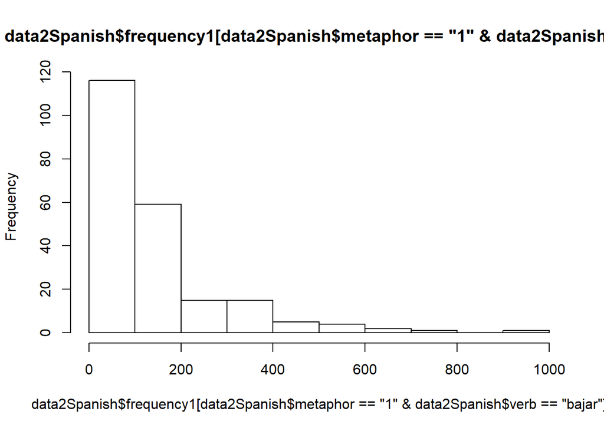

```r
hist(data2Spanish$frequency1[data2Spanish$metaphor == '1' & data2Spanish$verb == 'bajar'])
```

# Spanish

# If presenting the whole number of cases in 100 %, we can see the following picture, which show that 50% of all nouns are presented with tree Spanish verbs. At the same time, “bajar” contains 75% metaphors. However, here we deal with all nouns, not taking into consideration their frequency. But I will do later.

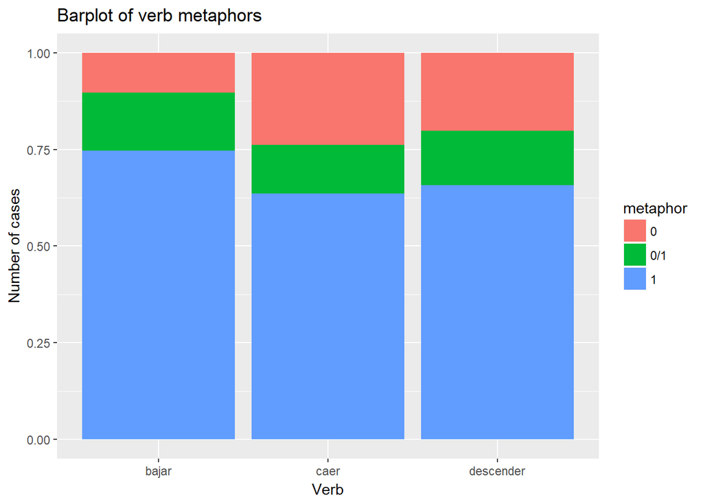

```r
ggplot(data2Spanish[is.na(data2Spanish$metaphor) == F, ], aes(verb))+
  geom_bar(aes(fill = metaphor), position = position_fill())+
  scale_y_continuous('Number of cases')+
  scale_x_discrete('Verb')+
  ggtitle('Barplot of verb metaphors')
```

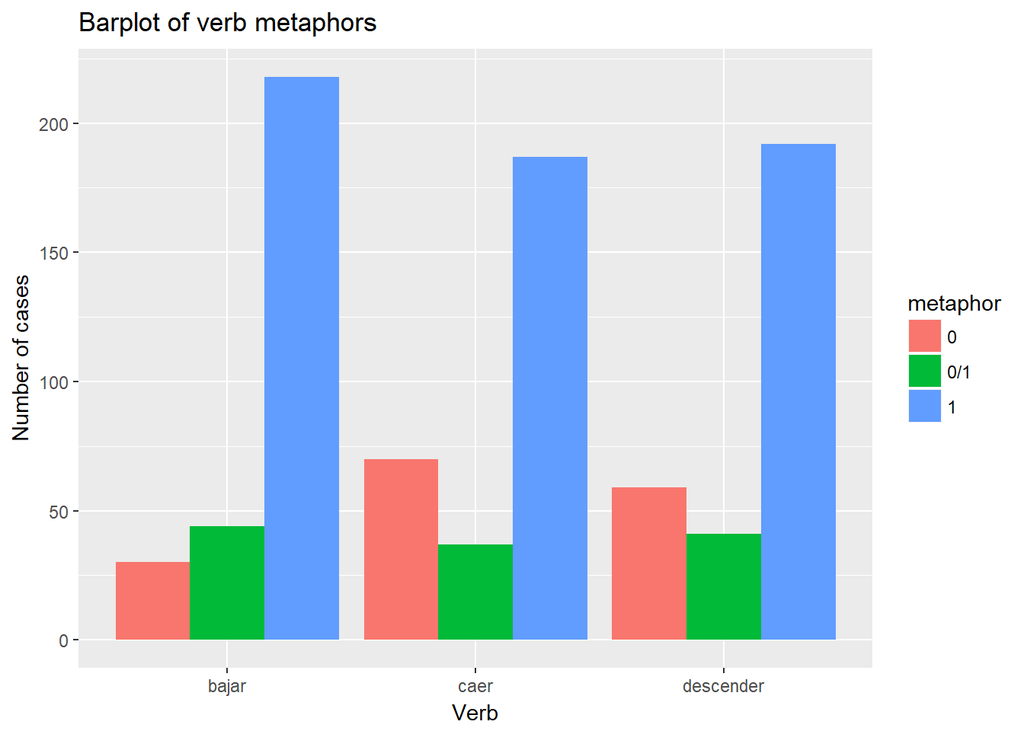

```r
ggplot(data2Spanish[is.na(data2Spanish$metaphor) == F, ], aes(verb))+
  geom_bar(aes(fill = metaphor), position = position_dodge())+
  scale_y_continuous('Number of cases')+
  scale_x_discrete('Verb')+
  ggtitle('Barplot of verb metaphors')
```

# Spanish: the most frequent verb.This verb is “caer”.

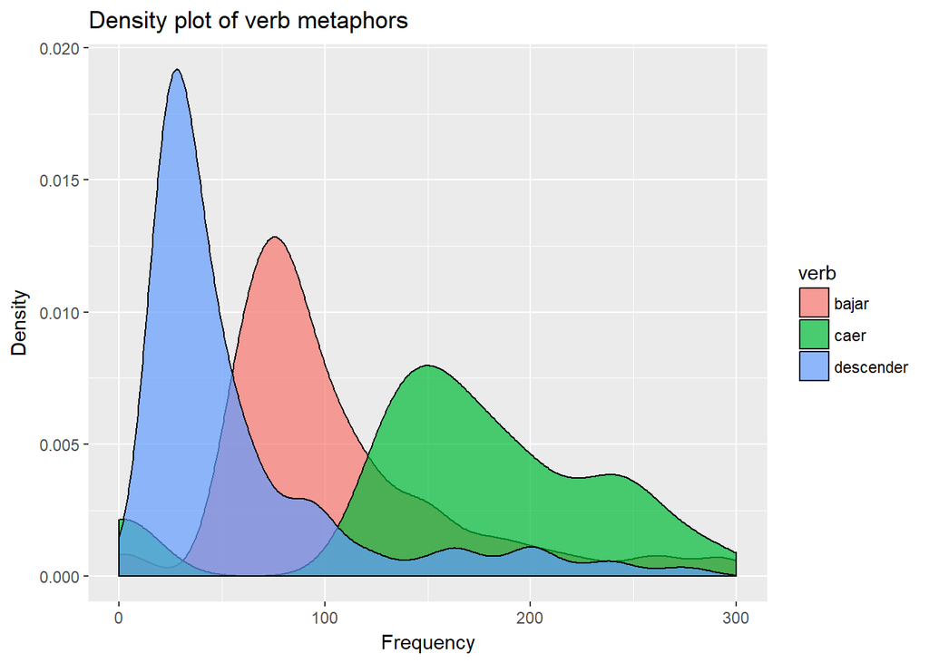

```r
ggplot(data2Spanish[data2Spanish$metaphor == '1', ], aes(x = frequency1))+
  geom_density(aes(fill = verb), alpha = 0.7)+
  scale_y_continuous('Density')+
  scale_x_continuous('Frequency', limits = c(0, 300))+
  ggtitle('Density plot of verb metaphors')
```

# Barplots of metaphors for each and every verb (French). Here the 0-hypothesis is challanged. Every verb shows high level of collocability.

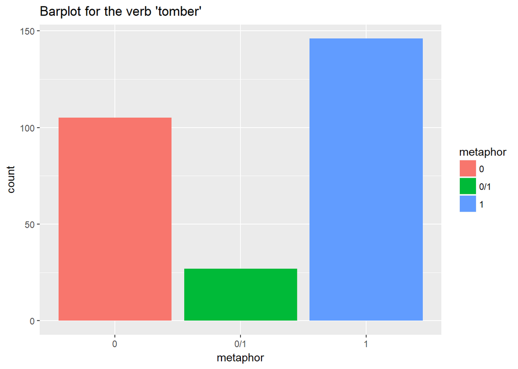

```r
ggplot(data1French[is.na(data1French$metaphor) == F & data1French$verb == 'tomber', ], aes(metaphor))+
  geom_bar(aes(fill = metaphor))+
  ggtitle('Barplot for the verb \'tomber\'')
```

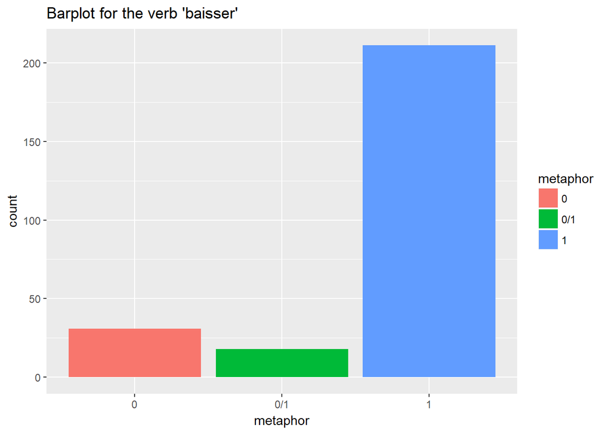

```r
ggplot(data1French[is.na(data1French$metaphor) == F & data1French$verb == 'baisser', ], aes(metaphor))+
  geom_bar(aes(fill = metaphor))+
  ggtitle('Barplot for the verb \'baisser\'')
```

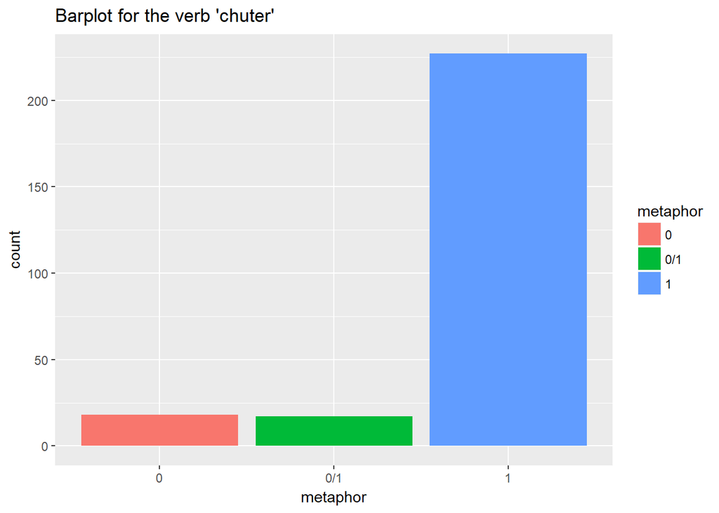

```r
ggplot(data1French[is.na(data1French$metaphor) == F & data1French$verb == 'chuter', ], aes(metaphor))+
  geom_bar(aes(fill = metaphor))+
  ggtitle('Barplot for the verb \'chuter\'')
```